# Отчет по лабораторной работе №7

Простейший шаблон

Чилеше . Л

Российский университет дружбы народов, Москва, Россия

Объединённый институт ядерных исследований, Дубна, Россия

# Информация

## Докладчик

- Лупупа Чилеше
- Студент
- Студент Группы НПИбд-03-23
- Российский университет дружбы народов

# Вводная часть

## Цель работы

Получение навыков работы с планировщиками событий cron и at.

# Выполнение лабораторной работы

## systemctl status crond -l

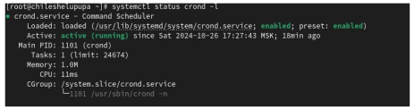

## cat /etc/crontab

[figure not shown]

## crontab -l

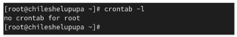

## */1* * * * logger This message is written from root cron

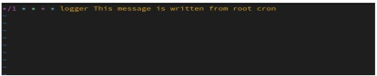

## crontab -l

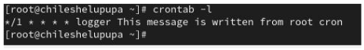

## grep written /var/log/messages

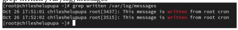

## 0 */1* * 1-5 logger This message is written from root cron

[figure not shown]

## crontab -l

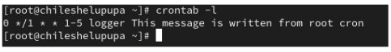

## cd /etc/cron.hourly

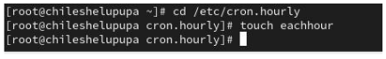

## logger This message is written at $(date)

Откройте файл eachhour для редактирования и пропишите в нём следующий скрипт (запись сообщения в системный журнал): #!/bin/sh logger This message is written at $(date)

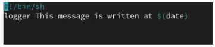

## chmod +x eachhour

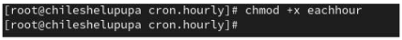

## 11 * * * * root logger This message is written from /etc/cron.d

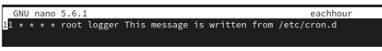

## grep written /var/log/messages

Не выключая систему, через некоторое время (2–3 часа) просмотрите журнал системных событий: grep written /var/log/messages По журналу определите, был ли осуществлён запуск сценария eachhour в соответствии с заданным расписанием.

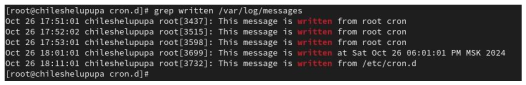

# Планирование заданий с помощью at

1. Запустите терминал и получите полномочия администратора: su –
2. Проверьте, что служба atd загружена и включена: systemctl status atd
3. Задайте выполнение команды logger message from at в 9:30 (или замените на любое другое время, когда вы работаете над этим упражнением). Для этого введите at 9:30 Затем введите logger message from at Используйте Ctrl + d , чтобы закрыть оболочку.
4. Убедитесь, что задание действительно запланировано: atq С помощью команды grep ‘from at’ /var/log/messages посмотрите, появилось ли соответствующее сообщение в лог-файле в указанное вами время.